# Risk Factor Analysis

## Outcome Variable

**Outcome Variable:** ever_stunted

## Predictor Variables

**Intervention Variable:** born_wasted

**Adjustment Set:**

unadjusted

## Stratifying Variables

The analysis was stratified on these variable(s):

- agecat
- studyid
- country

## Data Summary

| agecat | studyid | country | born_wasted | ever_stunted | n_cell | n |
| --- | --- | --- | --- | --- | --- | --- |
| 0-3 months | ki0047075b-MAL-ED | BANGLADESH | 0 | 0 | 179 | 244 |
| 0-3 months | ki0047075b-MAL-ED | BANGLADESH | 0 | 1 | 25 | 244 |
| 0-3 months | ki0047075b-MAL-ED | BANGLADESH | 1 | 0 | 37 | 244 |
| 0-3 months | ki0047075b-MAL-ED | BANGLADESH | 1 | 1 | 3 | 244 |
| 0-3 months | ki0047075b-MAL-ED | BRAZIL | 0 | 0 | 164 | 183 |
| 0-3 months | ki0047075b-MAL-ED | BRAZIL | 0 | 1 | 13 | 183 |
| 0-3 months | ki0047075b-MAL-ED | BRAZIL | 1 | 0 | 6 | 183 |
| 0-3 months | ki0047075b-MAL-ED | BRAZIL | 1 | 1 | 0 | 183 |
| 0-3 months | ki0047075b-MAL-ED | INDIA | 0 | 0 | 151 | 204 |
| 0-3 months | ki0047075b-MAL-ED | INDIA | 0 | 1 | 19 | 204 |
| 0-3 months | ki0047075b-MAL-ED | INDIA | 1 | 0 | 30 | 204 |
| 0-3 months | ki0047075b-MAL-ED | INDIA | 1 | 1 | 4 | 204 |
| 0-3 months | ki0047075b-MAL-ED | NEPAL | 0 | 0 | 142 | 168 |
| 0-3 months | ki0047075b-MAL-ED | NEPAL | 0 | 1 | 6 | 168 |
| 0-3 months | ki0047075b-MAL-ED | NEPAL | 1 | 0 | 19 | 168 |
| 0-3 months | ki0047075b-MAL-ED | NEPAL | 1 | 1 | 1 | 168 |
| 0-3 months | ki0047075b-MAL-ED | PERU | 0 | 0 | 216 | 282 |
| 0-3 months | ki0047075b-MAL-ED | PERU | 0 | 1 | 60 | 282 |
| 0-3 months | ki0047075b-MAL-ED | PERU | 1 | 0 | 5 | 282 |
| 0-3 months | ki0047075b-MAL-ED | PERU | 1 | 1 | 1 | 282 |
| 0-3 months | ki0047075b-MAL-ED | SOUTH AFRICA | 0 | 0 | 201 | 258 |
| 0-3 months | ki0047075b-MAL-ED | SOUTH AFRICA | 0 | 1 | 39 | 258 |
| 0-3 months | ki0047075b-MAL-ED | SOUTH AFRICA | 1 | 0 | 17 | 258 |
| 0-3 months | ki0047075b-MAL-ED | SOUTH AFRICA | 1 | 1 | 1 | 258 |
| 0-3 months | ki0047075b-MAL-ED | TANZANIA, UNITED REPUBLIC OF | 0 | 0 | 125 | 145 |
| 0-3 months | ki0047075b-MAL-ED | TANZANIA, UNITED REPUBLIC OF | 0 | 1 | 18 | 145 |
| 0-3 months | ki0047075b-MAL-ED | TANZANIA, UNITED REPUBLIC OF | 1 | 0 | 2 | 145 |
| 0-3 months | ki0047075b-MAL-ED | TANZANIA, UNITED REPUBLIC OF | 1 | 1 | 0 | 145 |
| 0-3 months | ki1000108-CMC-V-BCS-2002 | INDIA | 0 | 0 | 56 | 84 |
| 0-3 months | ki1000108-CMC-V-BCS-2002 | INDIA | 0 | 1 | 18 | 84 |

[output cut: 410 more lines]

The following strata were considered:

- agecat: 0-3 months, studyid: ki0047075b-MAL-ED, country: BANGLADESH
- agecat: 0-3 months, studyid: ki0047075b-MAL-ED, country: BRAZIL
- agecat: 0-3 months, studyid: ki0047075b-MAL-ED, country: INDIA
- agecat: 0-3 months, studyid: ki0047075b-MAL-ED, country: NEPAL
- agecat: 0-3 months, studyid: ki0047075b-MAL-ED, country: PERU
- agecat: 0-3 months, studyid: ki0047075b-MAL-ED, country: SOUTH AFRICA
- agecat: 0-3 months, studyid: ki0047075b-MAL-ED, country: TANZANIA, UNITED REPUBLIC OF
- agecat: 0-3 months, studyid: ki1000108-CMC-V-BCS-2002, country: INDIA
- agecat: 0-3 months, studyid: ki1000108-IRC, country: INDIA
- agecat: 0-3 months, studyid: ki1000109-EE, country: PAKISTAN
- agecat: 0-3 months, studyid: ki1000109-ResPak, country: PAKISTAN
- agecat: 0-3 months, studyid: ki1000304b-SAS-CompFeed, country: INDIA
- agecat: 0-3 months, studyid: ki1017093-NIH-Birth, country: BANGLADESH
- agecat: 0-3 months, studyid: ki1017093b-PROVIDE, country: BANGLADESH
- agecat: 0-3 months, studyid: ki1017093c-NIH-Crypto, country: BANGLADESH
- agecat: 0-3 months, studyid: ki1101329-Keneba, country: GAMBIA
- agecat: 0-3 months, studyid: ki1114097-CMIN, country: BANGLADESH
- agecat: 0-3 months, studyid: ki1114097-CMIN, country: BRAZIL
- agecat: 0-3 months, studyid: ki1114097-CMIN, country: GUINEA-BISSAU
- agecat: 0-3 months, studyid: ki1114097-CMIN, country: PERU
- agecat: 0-3 months, studyid: ki1114097-CONTENT, country: PERU
- agecat: 0-3 months, studyid: ki1119695-PROBIT, country: BELARUS
- agecat: 0-3 months, studyid: ki1126311-ZVITAMBO, country: ZIMBABWE
- agecat: 0-3 months, studyid: ki1135781-COHORTS, country: GUATEMALA
- agecat: 0-3 months, studyid: ki1135781-COHORTS, country: INDIA
- agecat: 0-3 months, studyid: ki1135781-COHORTS, country: PHILIPPINES
- agecat: 0-3 months, studyid: kiGH5241-JiVitA-3, country: BANGLADESH
- agecat: 0-3 months, studyid: kiGH5241-JiVitA-4, country: BANGLADESH
- agecat: 12-24 months, studyid: ki0047075b-MAL-ED, country: BANGLADESH
- agecat: 12-24 months, studyid: ki0047075b-MAL-ED, country: BRAZIL
- agecat: 12-24 months, studyid: ki0047075b-MAL-ED, country: INDIA
- agecat: 12-24 months, studyid: ki0047075b-MAL-ED, country: NEPAL
- agecat: 12-24 months, studyid: ki0047075b-MAL-ED, country: PERU
- agecat: 12-24 months, studyid: ki0047075b-MAL-ED, country: SOUTH AFRICA
- agecat: 12-24 months, studyid: ki0047075b-MAL-ED, country: TANZANIA, UNITED REPUBLIC OF
- agecat: 12-24 months, studyid: ki1000108-CMC-V-BCS-2002, country: INDIA
- agecat: 12-24 months, studyid: ki1000108-IRC, country: INDIA
- agecat: 12-24 months, studyid: ki1000109-EE, country: PAKISTAN
- agecat: 12-24 months, studyid: ki1000109-ResPak, country: PAKISTAN
- agecat: 12-24 months, studyid: ki1000304b-SAS-CompFeed, country: INDIA
- agecat: 12-24 months, studyid: ki1017093-NIH-Birth, country: BANGLADESH
- agecat: 12-24 months, studyid: ki1017093b-PROVIDE, country: BANGLADESH
- agecat: 12-24 months, studyid: ki1017093c-NIH-Crypto, country: BANGLADESH
- agecat: 12-24 months, studyid: ki1101329-Keneba, country: GAMBIA
- agecat: 12-24 months, studyid: ki1114097-CMIN, country: BANGLADESH
- agecat: 12-24 months, studyid: ki1114097-CMIN, country: BRAZIL
- agecat: 12-24 months, studyid: ki1114097-CMIN, country: GUINEA-BISSAU
- agecat: 12-24 months, studyid: ki1114097-CMIN, country: PERU
- agecat: 12-24 months, studyid: ki1114097-CONTENT, country: PERU
- agecat: 12-24 months, studyid: ki1119695-PROBIT, country: BELARUS
- agecat: 12-24 months, studyid: ki1126311-ZVITAMBO, country: ZIMBABWE
- agecat: 12-24 months, studyid: ki1135781-COHORTS, country: GUATEMALA
- agecat: 12-24 months, studyid: ki1135781-COHORTS, country: PHILIPPINES
- agecat: 12-24 months, studyid: kiGH5241-JiVitA-3, country: BANGLADESH
- agecat: 12-24 months, studyid: kiGH5241-JiVitA-4, country: BANGLADESH
- agecat: 3-6 months, studyid: ki0047075b-MAL-ED, country: BANGLADESH
- agecat: 3-6 months, studyid: ki0047075b-MAL-ED, country: BRAZIL
- agecat: 3-6 months, studyid: ki0047075b-MAL-ED, country: INDIA
- agecat: 3-6 months, studyid: ki0047075b-MAL-ED, country: NEPAL
- agecat: 3-6 months, studyid: ki0047075b-MAL-ED, country: PERU
- agecat: 3-6 months, studyid: ki0047075b-MAL-ED, country: SOUTH AFRICA
- agecat: 3-6 months, studyid: ki0047075b-MAL-ED, country: TANZANIA, UNITED REPUBLIC OF
- agecat: 3-6 months, studyid: ki1000108-CMC-V-BCS-2002, country: INDIA
- agecat: 3-6 months, studyid: ki1000108-IRC, country: INDIA
- agecat: 3-6 months, studyid: ki1000109-EE, country: PAKISTAN
- agecat: 3-6 months, studyid: ki1000109-ResPak, country: PAKISTAN
- agecat: 3-6 months, studyid: ki1000304b-SAS-CompFeed, country: INDIA
- agecat: 3-6 months, studyid: ki1017093-NIH-Birth, country: BANGLADESH
- agecat: 3-6 months, studyid: ki1017093b-PROVIDE, country: BANGLADESH
- agecat: 3-6 months, studyid: ki1017093c-NIH-Crypto, country: BANGLADESH
- agecat: 3-6 months, studyid: ki1101329-Keneba, country: GAMBIA
- agecat: 3-6 months, studyid: ki1114097-CMIN, country: BANGLADESH
- agecat: 3-6 months, studyid: ki1114097-CMIN, country: BRAZIL
- agecat: 3-6 months, studyid: ki1114097-CMIN, country: GUINEA-BISSAU
- agecat: 3-6 months, studyid: ki1114097-CMIN, country: PERU
- agecat: 3-6 months, studyid: ki1114097-CONTENT, country: PERU
- agecat: 3-6 months, studyid: ki1119695-PROBIT, country: BELARUS
- agecat: 3-6 months, studyid: ki1126311-ZVITAMBO, country: ZIMBABWE
- agecat: 3-6 months, studyid: ki1135781-COHORTS, country: GUATEMALA
- agecat: 3-6 months, studyid: ki1135781-COHORTS, country: PHILIPPINES
- agecat: 3-6 months, studyid: kiGH5241-JiVitA-3, country: BANGLADESH
- agecat: 3-6 months, studyid: kiGH5241-JiVitA-4, country: BANGLADESH
- agecat: 6-12 months, studyid: ki0047075b-MAL-ED, country: BANGLADESH
- agecat: 6-12 months, studyid: ki0047075b-MAL-ED, country: BRAZIL
- agecat: 6-12 months, studyid: ki0047075b-MAL-ED, country: INDIA
- agecat: 6-12 months, studyid: ki0047075b-MAL-ED, country: NEPAL
- agecat: 6-12 months, studyid: ki0047075b-MAL-ED, country: PERU
- agecat: 6-12 months, studyid: ki0047075b-MAL-ED, country: SOUTH AFRICA
- agecat: 6-12 months, studyid: ki0047075b-MAL-ED, country: TANZANIA, UNITED REPUBLIC OF
- agecat: 6-12 months, studyid: ki1000108-CMC-V-BCS-2002, country: INDIA
- agecat: 6-12 months, studyid: ki1000108-IRC, country: INDIA
- agecat: 6-12 months, studyid: ki1000109-EE, country: PAKISTAN
- agecat: 6-12 months, studyid: ki1000109-ResPak, country: PAKISTAN
- agecat: 6-12 months, studyid: ki1000304b-SAS-CompFeed, country: INDIA
- agecat: 6-12 months, studyid: ki1017093-NIH-Birth, country: BANGLADESH
- agecat: 6-12 months, studyid: ki1017093b-PROVIDE, country: BANGLADESH
- agecat: 6-12 months, studyid: ki1017093c-NIH-Crypto, country: BANGLADESH
- agecat: 6-12 months, studyid: ki1101329-Keneba, country: GAMBIA
- agecat: 6-12 months, studyid: ki1114097-CMIN, country: BANGLADESH
- agecat: 6-12 months, studyid: ki1114097-CMIN, country: BRAZIL
- agecat: 6-12 months, studyid: ki1114097-CMIN, country: GUINEA-BISSAU
- agecat: 6-12 months, studyid: ki1114097-CMIN, country: PERU
- agecat: 6-12 months, studyid: ki1114097-CONTENT, country: PERU
- agecat: 6-12 months, studyid: ki1119695-PROBIT, country: BELARUS
- agecat: 6-12 months, studyid: ki1126311-ZVITAMBO, country: ZIMBABWE
- agecat: 6-12 months, studyid: ki1135781-COHORTS, country: GUATEMALA
- agecat: 6-12 months, studyid: ki1135781-COHORTS, country: INDIA
- agecat: 6-12 months, studyid: ki1135781-COHORTS, country: PHILIPPINES
- agecat: 6-12 months, studyid: kiGH5241-JiVitA-3, country: BANGLADESH
- agecat: 6-12 months, studyid: kiGH5241-JiVitA-4, country: BANGLADESH

### Dropped Strata

Some strata were dropped due to rare outcomes:

- agecat: 0-3 months, studyid: ki0047075b-MAL-ED, country: BANGLADESH
- agecat: 0-3 months, studyid: ki0047075b-MAL-ED, country: BRAZIL
- agecat: 0-3 months, studyid: ki0047075b-MAL-ED, country: INDIA
- agecat: 0-3 months, studyid: ki0047075b-MAL-ED, country: NEPAL
- agecat: 0-3 months, studyid: ki0047075b-MAL-ED, country: PERU
- agecat: 0-3 months, studyid: ki0047075b-MAL-ED, country: SOUTH AFRICA
- agecat: 0-3 months, studyid: ki0047075b-MAL-ED, country: TANZANIA, UNITED REPUBLIC OF
- agecat: 0-3 months, studyid: ki1000108-CMC-V-BCS-2002, country: INDIA
- agecat: 0-3 months, studyid: ki1000109-ResPak, country: PAKISTAN
- agecat: 0-3 months, studyid: ki1114097-CMIN, country: BANGLADESH
- agecat: 0-3 months, studyid: ki1114097-CMIN, country: BRAZIL
- agecat: 0-3 months, studyid: ki1114097-CMIN, country: GUINEA-BISSAU
- agecat: 0-3 months, studyid: ki1114097-CMIN, country: PERU
- agecat: 0-3 months, studyid: ki1114097-CONTENT, country: PERU
- agecat: 0-3 months, studyid: kiGH5241-JiVitA-4, country: BANGLADESH
- agecat: 3-6 months, studyid: ki0047075b-MAL-ED, country: BANGLADESH
- agecat: 3-6 months, studyid: ki0047075b-MAL-ED, country: BRAZIL
- agecat: 3-6 months, studyid: ki0047075b-MAL-ED, country: INDIA
- agecat: 3-6 months, studyid: ki0047075b-MAL-ED, country: NEPAL
- agecat: 3-6 months, studyid: ki0047075b-MAL-ED, country: PERU
- agecat: 3-6 months, studyid: ki0047075b-MAL-ED, country: SOUTH AFRICA
- agecat: 3-6 months, studyid: ki0047075b-MAL-ED, country: TANZANIA, UNITED REPUBLIC OF
- agecat: 3-6 months, studyid: ki1000108-CMC-V-BCS-2002, country: INDIA
- agecat: 3-6 months, studyid: ki1000109-ResPak, country: PAKISTAN
- agecat: 3-6 months, studyid: ki1101329-Keneba, country: GAMBIA
- agecat: 3-6 months, studyid: ki1114097-CMIN, country: BANGLADESH
- agecat: 3-6 months, studyid: ki1114097-CMIN, country: BRAZIL
- agecat: 3-6 months, studyid: ki1114097-CMIN, country: GUINEA-BISSAU
- agecat: 3-6 months, studyid: ki1114097-CMIN, country: PERU
- agecat: 3-6 months, studyid: ki1114097-CONTENT, country: PERU
- agecat: 6-12 months, studyid: ki0047075b-MAL-ED, country: BRAZIL
- agecat: 6-12 months, studyid: ki0047075b-MAL-ED, country: INDIA
- agecat: 6-12 months, studyid: ki0047075b-MAL-ED, country: NEPAL
- agecat: 6-12 months, studyid: ki0047075b-MAL-ED, country: PERU
- agecat: 6-12 months, studyid: ki0047075b-MAL-ED, country: SOUTH AFRICA
- agecat: 6-12 months, studyid: ki0047075b-MAL-ED, country: TANZANIA, UNITED REPUBLIC OF
- agecat: 6-12 months, studyid: ki1000108-CMC-V-BCS-2002, country: INDIA
- agecat: 6-12 months, studyid: ki1000109-EE, country: PAKISTAN
- agecat: 6-12 months, studyid: ki1000109-ResPak, country: PAKISTAN
- agecat: 6-12 months, studyid: ki1101329-Keneba, country: GAMBIA
- agecat: 6-12 months, studyid: ki1114097-CMIN, country: BANGLADESH
- agecat: 6-12 months, studyid: ki1114097-CMIN, country: BRAZIL
- agecat: 6-12 months, studyid: ki1114097-CMIN, country: GUINEA-BISSAU
- agecat: 6-12 months, studyid: ki1114097-CMIN, country: PERU
- agecat: 6-12 months, studyid: ki1114097-CONTENT, country: PERU
- agecat: 12-24 months, studyid: ki0047075b-MAL-ED, country: BRAZIL
- agecat: 12-24 months, studyid: ki0047075b-MAL-ED, country: INDIA
- agecat: 12-24 months, studyid: ki0047075b-MAL-ED, country: PERU
- agecat: 12-24 months, studyid: ki0047075b-MAL-ED, country: SOUTH AFRICA
- agecat: 12-24 months, studyid: ki0047075b-MAL-ED, country: TANZANIA, UNITED REPUBLIC OF
- agecat: 12-24 months, studyid: ki1000108-CMC-V-BCS-2002, country: INDIA
- agecat: 12-24 months, studyid: ki1000109-EE, country: PAKISTAN
- agecat: 12-24 months, studyid: ki1000109-ResPak, country: PAKISTAN
- agecat: 12-24 months, studyid: ki1101329-Keneba, country: GAMBIA
- agecat: 12-24 months, studyid: ki1114097-CMIN, country: BANGLADESH
- agecat: 12-24 months, studyid: ki1114097-CMIN, country: BRAZIL
- agecat: 12-24 months, studyid: ki1114097-CMIN, country: GUINEA-BISSAU
- agecat: 12-24 months, studyid: ki1114097-CMIN, country: PERU
- agecat: 12-24 months, studyid: ki1114097-CONTENT, country: PERU

## Methods Detail

We’re interested in the causal parameters $E[Y_a]$ for all values of $a \in \mathcal{A}$. These parameters represent the mean outcome if, possibly contrary to fact, we intervened to set all units to have $A=a$. Under the randomization and positivity assumptions, these are identified by the statistical parameters $\psi_a=E_W[E_{Y|A,W}(Y|A=a,W)]$. In addition, we’re interested in the mean of $Y$, $E[Y]$ under no intervention (the observed mean). We will estimate these parameters by using SuperLearner to fit the relevant likelihood factors – $E_{Y|A,W}(Y|A=a,W)$ and $p(A=a|W)$, and then updating our likelihood fit using a joint TMLE.

For unadjusted analyses ($W=\{\}$), initial likelihoods were estimated using Lrnr_glm to estimate the simple $E(Y|A)$ and Lrnr_mean to estimate $p(A)$. For adjusted analyses, a small library containing Lrnr_glmnet, Lrnr_xgboost, and Lrnr_mean was used.

Having estimated these parameters, we will then use the delta method to estimate relative risks and attributable risks relative to a prespecified baseline level of $A$.

# Results Detail

## Results Plots

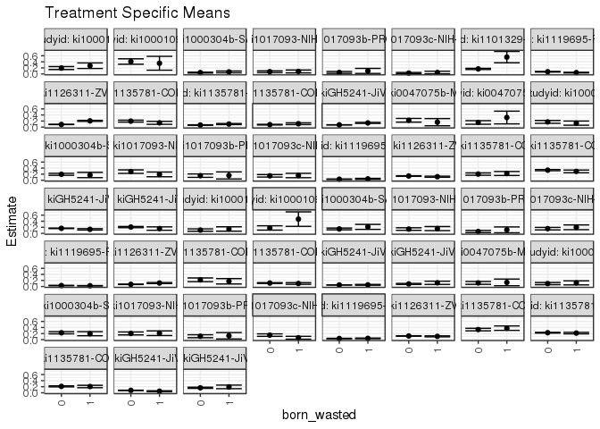

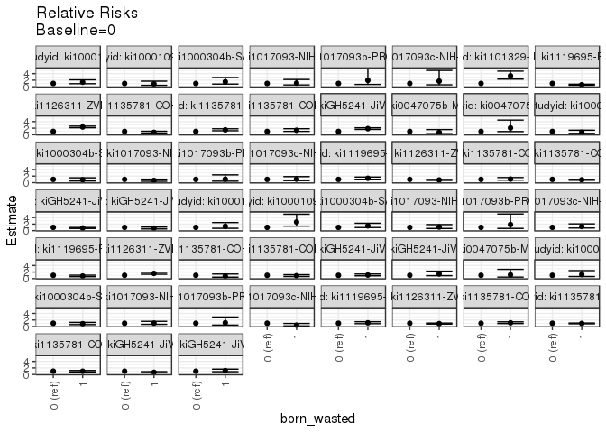

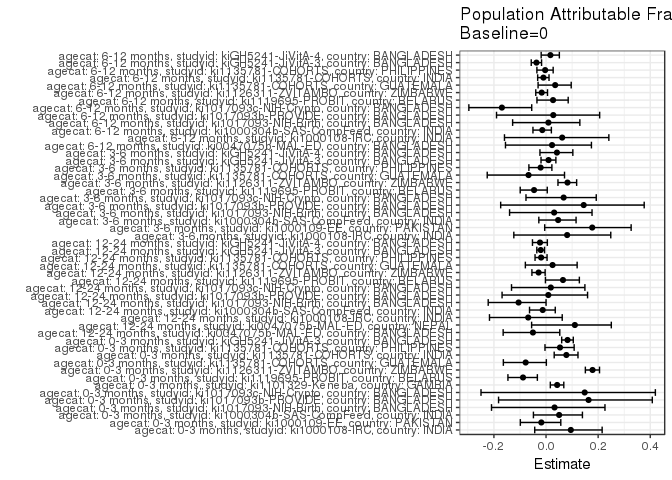

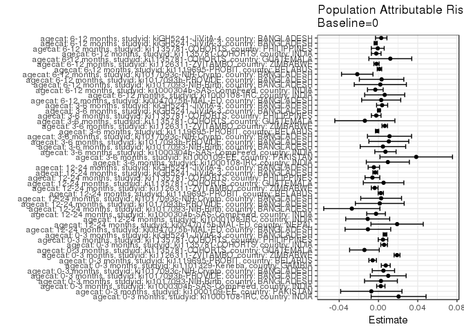

## Results Table

### Parameter: TSM

| agecat | studyid | country | intervention_level | baseline_level | estimate | ci_lower | ci_upper |
| --- | --- | --- | --- | --- | --- | --- | --- |
| 0-3 months | ki1000108-IRC | INDIA | 0 | NA | 0.1952191 | 0.1461119 | 0.2443263 |
| 0-3 months | ki1000108-IRC | INDIA | 1 | NA | 0.2717391 | 0.1807043 | 0.3627740 |
| 0-3 months | ki1000109-EE | PAKISTAN | 0 | NA | 0.4102564 | 0.3207939 | 0.4997189 |
| 0-3 months | ki1000109-EE | PAKISTAN | 1 | NA | 0.3529412 | 0.1249210 | 0.5809613 |
| 0-3 months | ki1000304b-SAS-CompFeed | INDIA | 0 | NA | 0.0454545 | 0.0319132 | 0.0589959 |
| 0-3 months | ki1000304b-SAS-CompFeed | INDIA | 1 | NA | 0.0686275 | 0.0388705 | 0.0983844 |
| 0-3 months | ki1017093-NIH-Birth | BANGLADESH | 0 | NA | 0.0749186 | 0.0454364 | 0.1044007 |
| 0-3 months | ki1017093-NIH-Birth | BANGLADESH | 1 | NA | 0.0833333 | 0.0361301 | 0.1305365 |
| 0-3 months | ki1017093b-PROVIDE | BANGLADESH | 0 | NA | 0.0510204 | 0.0201527 | 0.0818882 |
| 0-3 months | ki1017093b-PROVIDE | BANGLADESH | 1 | NA | 0.1000000 | 0.0166762 | 0.1833238 |
| 0-3 months | ki1017093c-NIH-Crypto | BANGLADESH | 0 | NA | 0.0289389 | 0.0102854 | 0.0475924 |
| 0-3 months | ki1017093c-NIH-Crypto | BANGLADESH | 1 | NA | 0.0495050 | 0.0071490 | 0.0918609 |
| 0-3 months | ki1101329-Keneba | GAMBIA | 0 | NA | 0.1669075 | 0.1472550 | 0.1865600 |
| 0-3 months | ki1101329-Keneba | GAMBIA | 1 | NA | 0.5555556 | 0.3680593 | 0.7430518 |
| 0-3 months | ki1119695-PROBIT | BELARUS | 0 | NA | 0.0729633 | 0.0627173 | 0.0832094 |
| 0-3 months | ki1119695-PROBIT | BELARUS | 1 | NA | 0.0442882 | 0.0342680 | 0.0543085 |
| 0-3 months | ki1126311-ZVITAMBO | ZIMBABWE | 0 | NA | 0.0871408 | 0.0818351 | 0.0924464 |
| 0-3 months | ki1126311-ZVITAMBO | ZIMBABWE | 1 | NA | 0.2059252 | 0.1884581 | 0.2233924 |
| 0-3 months | ki1135781-COHORTS | GUATEMALA | 0 | NA | 0.1968085 | 0.1639742 | 0.2296428 |
| 0-3 months | ki1135781-COHORTS | GUATEMALA | 1 | NA | 0.1406250 | 0.0914202 | 0.1898298 |
| 0-3 months | ki1135781-COHORTS | INDIA | 0 | NA | 0.0678831 | 0.0609768 | 0.0747893 |
| 0-3 months | ki1135781-COHORTS | INDIA | 1 | NA | 0.1003650 | 0.0825739 | 0.1181560 |
| 0-3 months | ki1135781-COHORTS | PHILIPPINES | 0 | NA | 0.0812908 | 0.0704634 | 0.0921183 |
| 0-3 months | ki1135781-COHORTS | PHILIPPINES | 1 | NA | 0.1108647 | 0.0818836 | 0.1398459 |
| 0-3 months | kiGH5241-JiVitA-3 | BANGLADESH | 0 | NA | 0.0740788 | 0.0698280 | 0.0783296 |
| 0-3 months | kiGH5241-JiVitA-3 | BANGLADESH | 1 | NA | 0.1370450 | 0.1203980 | 0.1536919 |
| 3-6 months | ki1000108-IRC | INDIA | 0 | NA | 0.1084337 | 0.0697571 | 0.1471104 |
| 3-6 months | ki1000108-IRC | INDIA | 1 | NA | 0.1444444 | 0.0717095 | 0.2171793 |
| 3-6 months | ki1000109-EE | PAKISTAN | 0 | NA | 0.1785714 | 0.1073649 | 0.2497780 |
| 3-6 months | ki1000109-EE | PAKISTAN | 1 | NA | 0.4705882 | 0.2323942 | 0.7087822 |

[output cut: 72 more lines]

### Parameter: E(Y)

| agecat | studyid | country | intervention_level | baseline_level | estimate | ci_lower | ci_upper |
| --- | --- | --- | --- | --- | --- | --- | --- |
| 0-3 months | ki1000108-IRC | INDIA | NA | NA | 0.2157434 | 0.1721488 | 0.2593381 |
| 0-3 months | ki1000109-EE | PAKISTAN | NA | NA | 0.4029851 | 0.3196248 | 0.4863454 |
| 0-3 months | ki1000304b-SAS-CompFeed | INDIA | NA | NA | 0.0478615 | 0.0366224 | 0.0591006 |
| 0-3 months | ki1017093-NIH-Birth | BANGLADESH | NA | NA | 0.0774487 | 0.0524157 | 0.1024818 |
| 0-3 months | ki1017093b-PROVIDE | BANGLADESH | NA | NA | 0.0609756 | 0.0310129 | 0.0909384 |
| 0-3 months | ki1017093c-NIH-Crypto | BANGLADESH | NA | NA | 0.0339806 | 0.0164646 | 0.0514966 |
| 0-3 months | ki1101329-Keneba | GAMBIA | NA | NA | 0.1743444 | 0.1545409 | 0.1941479 |
| 0-3 months | ki1119695-PROBIT | BELARUS | NA | NA | 0.0670440 | 0.0582181 | 0.0758698 |
| 0-3 months | ki1126311-ZVITAMBO | ZIMBABWE | NA | NA | 0.1060782 | 0.1007672 | 0.1113893 |
| 0-3 months | ki1135781-COHORTS | GUATEMALA | NA | NA | 0.1825397 | 0.1549856 | 0.2100938 |
| 0-3 months | ki1135781-COHORTS | INDIA | NA | NA | 0.0736315 | 0.0671264 | 0.0801367 |
| 0-3 months | ki1135781-COHORTS | PHILIPPINES | NA | NA | 0.0858917 | 0.0756900 | 0.0960934 |
| 0-3 months | kiGH5241-JiVitA-3 | BANGLADESH | NA | NA | 0.0807485 | 0.0765206 | 0.0849764 |
| 3-6 months | ki1000108-IRC | INDIA | NA | NA | 0.1179941 | 0.0836022 | 0.1523860 |
| 3-6 months | ki1000109-EE | PAKISTAN | NA | NA | 0.2170543 | 0.1456387 | 0.2884699 |
| 3-6 months | ki1000304b-SAS-CompFeed | INDIA | NA | NA | 0.1533666 | 0.1270023 | 0.1797309 |
| 3-6 months | ki1017093-NIH-Birth | BANGLADESH | NA | NA | 0.1469072 | 0.1116367 | 0.1821778 |
| 3-6 months | ki1017093b-PROVIDE | BANGLADESH | NA | NA | 0.0730594 | 0.0385145 | 0.1076042 |
| 3-6 months | ki1017093c-NIH-Crypto | BANGLADESH | NA | NA | 0.1666667 | 0.1299145 | 0.2034189 |
| 3-6 months | ki1119695-PROBIT | BELARUS | NA | NA | 0.0300481 | 0.0231480 | 0.0369482 |
| 3-6 months | ki1126311-ZVITAMBO | ZIMBABWE | NA | NA | 0.0781344 | 0.0723668 | 0.0839020 |
| 3-6 months | ki1135781-COHORTS | GUATEMALA | NA | NA | 0.2064777 | 0.1558957 | 0.2570598 |
| 3-6 months | ki1135781-COHORTS | PHILIPPINES | NA | NA | 0.1113193 | 0.0993824 | 0.1232563 |
| 3-6 months | kiGH5241-JiVitA-3 | BANGLADESH | NA | NA | 0.0512800 | 0.0470124 | 0.0555477 |
| 3-6 months | kiGH5241-JiVitA-4 | BANGLADESH | NA | NA | 0.0891304 | 0.0736243 | 0.1046365 |
| 6-12 months | ki0047075b-MAL-ED | BANGLADESH | NA | NA | 0.1210762 | 0.0781644 | 0.1639880 |
| 6-12 months | ki1000108-IRC | INDIA | NA | NA | 0.1023392 | 0.0701694 | 0.1345090 |
| 6-12 months | ki1000304b-SAS-CompFeed | INDIA | NA | NA | 0.2234637 | 0.1907158 | 0.2562116 |
| 6-12 months | ki1017093-NIH-Birth | BANGLADESH | NA | NA | 0.2064343 | 0.1653043 | 0.2475643 |
| 6-12 months | ki1017093b-PROVIDE | BANGLADESH | NA | NA | 0.1150000 | 0.0706757 | 0.1593243 |
| 6-12 months | ki1017093c-NIH-Crypto | BANGLADESH | NA | NA | 0.1275510 | 0.0944858 | 0.1606163 |
| 6-12 months | ki1119695-PROBIT | BELARUS | NA | NA | 0.0377882 | 0.0302168 | 0.0453595 |
| 6-12 months | ki1126311-ZVITAMBO | ZIMBABWE | NA | NA | 0.1191219 | 0.1125355 | 0.1257083 |
| 6-12 months | ki1135781-COHORTS | GUATEMALA | NA | NA | 0.3440367 | 0.3076004 | 0.3804729 |
| 6-12 months | ki1135781-COHORTS | INDIA | NA | NA | 0.2261246 | 0.2153393 | 0.2369098 |
| 6-12 months | ki1135781-COHORTS | PHILIPPINES | NA | NA | 0.2099848 | 0.1943978 | 0.2255717 |
| 6-12 months | kiGH5241-JiVitA-3 | BANGLADESH | NA | NA | 0.0770470 | 0.0716324 | 0.0824616 |
| 6-12 months | kiGH5241-JiVitA-4 | BANGLADESH | NA | NA | 0.1667439 | 0.1481671 | 0.1853207 |
| 12-24 months | ki0047075b-MAL-ED | BANGLADESH | NA | NA | 0.2139535 | 0.1590089 | 0.2688981 |
| 12-24 months | ki0047075b-MAL-ED | NEPAL | NA | NA | 0.1717791 | 0.1136962 | 0.2298621 |
| 12-24 months | ki1000108-IRC | INDIA | NA | NA | 0.1603499 | 0.1214616 | 0.1992381 |
| 12-24 months | ki1000304b-SAS-CompFeed | INDIA | NA | NA | 0.1926606 | 0.1608065 | 0.2245146 |
| 12-24 months | ki1017093-NIH-Birth | BANGLADESH | NA | NA | 0.2573964 | 0.2107184 | 0.3040745 |
| 12-24 months | ki1017093b-PROVIDE | BANGLADESH | NA | NA | 0.1522843 | 0.1019837 | 0.2025848 |
| 12-24 months | ki1017093c-NIH-Crypto | BANGLADESH | NA | NA | 0.1480519 | 0.1125301 | 0.1835738 |
| 12-24 months | ki1119695-PROBIT | BELARUS | NA | NA | 0.0365150 | 0.0272579 | 0.0457720 |
| 12-24 months | ki1126311-ZVITAMBO | ZIMBABWE | NA | NA | 0.1352599 | 0.1270781 | 0.1434418 |
| 12-24 months | ki1135781-COHORTS | GUATEMALA | NA | NA | 0.2081129 | 0.1746687 | 0.2415571 |
| 12-24 months | ki1135781-COHORTS | PHILIPPINES | NA | NA | 0.3262495 | 0.3080166 | 0.3444824 |
| 12-24 months | kiGH5241-JiVitA-3 | BANGLADESH | NA | NA | 0.1624278 | 0.1545118 | 0.1703438 |
| 12-24 months | kiGH5241-JiVitA-4 | BANGLADESH | NA | NA | 0.2032864 | 0.1839142 | 0.2226586 |

### Parameter: RR

| agecat | studyid | country | intervention_level | baseline_level | estimate | ci_lower | ci_upper |
| --- | --- | --- | --- | --- | --- | --- | --- |
| 0-3 months | ki1000108-IRC | INDIA | 0 | 0 | 1.0000000 | 1.0000000 | 1.0000000 |
| 0-3 months | ki1000108-IRC | INDIA | 1 | 0 | 1.3919698 | 0.9155628 | 2.1162721 |
| 0-3 months | ki1000109-EE | PAKISTAN | 0 | 0 | 1.0000000 | 1.0000000 | 1.0000000 |
| 0-3 months | ki1000109-EE | PAKISTAN | 1 | 0 | 0.8602941 | 0.4350268 | 1.7012881 |
| 0-3 months | ki1000304b-SAS-CompFeed | INDIA | 0 | 0 | 1.0000000 | 1.0000000 | 1.0000000 |
| 0-3 months | ki1000304b-SAS-CompFeed | INDIA | 1 | 0 | 1.5098039 | 0.8115715 | 2.8087578 |
| 0-3 months | ki1017093-NIH-Birth | BANGLADESH | 0 | 0 | 1.0000000 | 1.0000000 | 1.0000000 |
| 0-3 months | ki1017093-NIH-Birth | BANGLADESH | 1 | 0 | 1.1123188 | 0.5580693 | 2.2170242 |
| 0-3 months | ki1017093b-PROVIDE | BANGLADESH | 0 | 0 | 1.0000000 | 1.0000000 | 1.0000000 |
| 0-3 months | ki1017093b-PROVIDE | BANGLADESH | 1 | 0 | 1.9600000 | 0.6999309 | 5.4885417 |
| 0-3 months | ki1017093c-NIH-Crypto | BANGLADESH | 0 | 0 | 1.0000000 | 1.0000000 | 1.0000000 |
| 0-3 months | ki1017093c-NIH-Crypto | BANGLADESH | 1 | 0 | 1.7106711 | 0.5860573 | 4.9933605 |
| 0-3 months | ki1101329-Keneba | GAMBIA | 0 | 0 | 1.0000000 | 1.0000000 | 1.0000000 |
| 0-3 months | ki1101329-Keneba | GAMBIA | 1 | 0 | 3.3285233 | 2.3281771 | 4.7586877 |
| 0-3 months | ki1119695-PROBIT | BELARUS | 0 | 0 | 1.0000000 | 1.0000000 | 1.0000000 |
| 0-3 months | ki1119695-PROBIT | BELARUS | 1 | 0 | 0.6069929 | 0.4737587 | 0.7776963 |
| 0-3 months | ki1126311-ZVITAMBO | ZIMBABWE | 0 | 0 | 1.0000000 | 1.0000000 | 1.0000000 |
| 0-3 months | ki1126311-ZVITAMBO | ZIMBABWE | 1 | 0 | 2.3631332 | 2.1288360 | 2.6232169 |
| 0-3 months | ki1135781-COHORTS | GUATEMALA | 0 | 0 | 1.0000000 | 1.0000000 | 1.0000000 |
| 0-3 months | ki1135781-COHORTS | GUATEMALA | 1 | 0 | 0.7145270 | 0.4849189 | 1.0528541 |
| 0-3 months | ki1135781-COHORTS | INDIA | 0 | 0 | 1.0000000 | 1.0000000 | 1.0000000 |
| 0-3 months | ki1135781-COHORTS | INDIA | 1 | 0 | 1.4784977 | 1.2051961 | 1.8137759 |
| 0-3 months | ki1135781-COHORTS | PHILIPPINES | 0 | 0 | 1.0000000 | 1.0000000 | 1.0000000 |
| 0-3 months | ki1135781-COHORTS | PHILIPPINES | 1 | 0 | 1.3638035 | 1.0170341 | 1.8288078 |
| 0-3 months | kiGH5241-JiVitA-3 | BANGLADESH | 0 | 0 | 1.0000000 | 1.0000000 | 1.0000000 |
| 0-3 months | kiGH5241-JiVitA-3 | BANGLADESH | 1 | 0 | 1.8499897 | 1.6183539 | 2.1147797 |
| 3-6 months | ki1000108-IRC | INDIA | 0 | 0 | 1.0000000 | 1.0000000 | 1.0000000 |
| 3-6 months | ki1000108-IRC | INDIA | 1 | 0 | 1.3320988 | 0.7186917 | 2.4690520 |
| 3-6 months | ki1000109-EE | PAKISTAN | 0 | 0 | 1.0000000 | 1.0000000 | 1.0000000 |
| 3-6 months | ki1000109-EE | PAKISTAN | 1 | 0 | 2.6352941 | 1.3835175 | 5.0196510 |

[output cut: 72 more lines]

### Parameter: PAR

| agecat | studyid | country | intervention_level | baseline_level | estimate | ci_lower | ci_upper |
| --- | --- | --- | --- | --- | --- | --- | --- |
| 0-3 months | ki1000108-IRC | INDIA | 0 | NA | 0.0205243 | -0.0074509 | 0.0484996 |
| 0-3 months | ki1000109-EE | PAKISTAN | 0 | NA | -0.0072713 | -0.0385148 | 0.0239721 |
| 0-3 months | ki1000304b-SAS-CompFeed | INDIA | 0 | NA | 0.0024070 | -0.0018247 | 0.0066386 |
| 0-3 months | ki1017093-NIH-Birth | BANGLADESH | 0 | NA | 0.0025302 | -0.0142079 | 0.0192682 |
| 0-3 months | ki1017093b-PROVIDE | BANGLADESH | 0 | NA | 0.0099552 | -0.0082731 | 0.0281835 |
| 0-3 months | ki1017093c-NIH-Crypto | BANGLADESH | 0 | NA | 0.0050417 | -0.0063362 | 0.0164196 |
| 0-3 months | ki1101329-Keneba | GAMBIA | 0 | NA | 0.0074369 | 0.0028831 | 0.0119908 |
| 0-3 months | ki1119695-PROBIT | BELARUS | 0 | NA | -0.0059194 | -0.0097666 | -0.0020722 |
| 0-3 months | ki1126311-ZVITAMBO | ZIMBABWE | 0 | NA | 0.0189375 | 0.0159320 | 0.0219429 |
| 0-3 months | ki1135781-COHORTS | GUATEMALA | 0 | NA | -0.0142688 | -0.0293930 | 0.0008554 |
| 0-3 months | ki1135781-COHORTS | INDIA | 0 | NA | 0.0057485 | 0.0023569 | 0.0091400 |
| 0-3 months | ki1135781-COHORTS | PHILIPPINES | 0 | NA | 0.0046008 | -0.0002280 | 0.0094296 |
| 0-3 months | kiGH5241-JiVitA-3 | BANGLADESH | 0 | NA | 0.0066697 | 0.0048335 | 0.0085060 |
| 3-6 months | ki1000108-IRC | INDIA | 0 | NA | 0.0095604 | -0.0123757 | 0.0314964 |
| 3-6 months | ki1000109-EE | PAKISTAN | 0 | NA | 0.0384828 | 0.0015208 | 0.0754449 |
| 3-6 months | ki1000304b-SAS-CompFeed | INDIA | 0 | NA | 0.0071270 | -0.0037018 | 0.0179558 |
| 3-6 months | ki1017093-NIH-Birth | BANGLADESH | 0 | NA | 0.0045715 | -0.0185892 | 0.0277321 |
| 3-6 months | ki1017093b-PROVIDE | BANGLADESH | 0 | NA | 0.0105594 | -0.0097656 | 0.0308844 |
| 3-6 months | ki1017093c-NIH-Crypto | BANGLADESH | 0 | NA | 0.0112613 | -0.0112218 | 0.0337443 |
| 3-6 months | ki1119695-PROBIT | BELARUS | 0 | NA | -0.0013794 | -0.0030779 | 0.0003191 |
| 3-6 months | ki1126311-ZVITAMBO | ZIMBABWE | 0 | NA | 0.0064325 | 0.0036001 | 0.0092650 |
| 3-6 months | ki1135781-COHORTS | GUATEMALA | 0 | NA | -0.0138613 | -0.0444693 | 0.0167468 |
| 3-6 months | ki1135781-COHORTS | PHILIPPINES | 0 | NA | -0.0023069 | -0.0072208 | 0.0026069 |
| 3-6 months | kiGH5241-JiVitA-3 | BANGLADESH | 0 | NA | 0.0004957 | -0.0009697 | 0.0019610 |
| 3-6 months | kiGH5241-JiVitA-4 | BANGLADESH | 0 | NA | 0.0037276 | -0.0019132 | 0.0093685 |
| 6-12 months | ki0047075b-MAL-ED | BANGLADESH | 0 | NA | 0.0027967 | -0.0170979 | 0.0226912 |
| 6-12 months | ki1000108-IRC | INDIA | 0 | NA | 0.0063392 | -0.0140819 | 0.0267603 |
| 6-12 months | ki1000304b-SAS-CompFeed | INDIA | 0 | NA | -0.0031864 | -0.0111781 | 0.0048053 |
| 6-12 months | ki1017093-NIH-Birth | BANGLADESH | 0 | NA | 0.0018889 | -0.0246668 | 0.0284445 |
| 6-12 months | ki1017093b-PROVIDE | BANGLADESH | 0 | NA | 0.0031988 | -0.0194306 | 0.0258281 |
| 6-12 months | ki1017093c-NIH-Crypto | BANGLADESH | 0 | NA | -0.0216015 | -0.0376161 | -0.0055870 |
| 6-12 months | ki1119695-PROBIT | BELARUS | 0 | NA | 0.0010167 | -0.0012561 | 0.0032895 |
| 6-12 months | ki1126311-ZVITAMBO | ZIMBABWE | 0 | NA | -0.0019788 | -0.0046675 | 0.0007100 |
| 6-12 months | ki1135781-COHORTS | GUATEMALA | 0 | NA | 0.0120779 | -0.0097763 | 0.0339321 |
| 6-12 months | ki1135781-COHORTS | INDIA | 0 | NA | -0.0022848 | -0.0072148 | 0.0026453 |
| 6-12 months | ki1135781-COHORTS | PHILIPPINES | 0 | NA | -0.0007071 | -0.0072604 | 0.0058463 |
| 6-12 months | kiGH5241-JiVitA-3 | BANGLADESH | 0 | NA | -0.0028335 | -0.0043658 | -0.0013012 |
| 6-12 months | kiGH5241-JiVitA-4 | BANGLADESH | 0 | NA | 0.0028094 | -0.0030110 | 0.0086298 |
| 12-24 months | ki0047075b-MAL-ED | BANGLADESH | 0 | NA | -0.0107656 | -0.0340379 | 0.0125066 |
| 12-24 months | ki0047075b-MAL-ED | NEPAL | 0 | NA | 0.0190014 | -0.0076316 | 0.0456343 |
| 12-24 months | ki1000108-IRC | INDIA | 0 | NA | -0.0109649 | -0.0333739 | 0.0114442 |
| 12-24 months | ki1000304b-SAS-CompFeed | INDIA | 0 | NA | -0.0024614 | -0.0119760 | 0.0070532 |
| 12-24 months | ki1017093-NIH-Birth | BANGLADESH | 0 | NA | -0.0271224 | -0.0557506 | 0.0015058 |
| 12-24 months | ki1017093b-PROVIDE | BANGLADESH | 0 | NA | 0.0013409 | -0.0235313 | 0.0262130 |
| 12-24 months | ki1017093c-NIH-Crypto | BANGLADESH | 0 | NA | 0.0027232 | -0.0180614 | 0.0235079 |
| 12-24 months | ki1119695-PROBIT | BELARUS | 0 | NA | 0.0023746 | -0.0003109 | 0.0050601 |
| 12-24 months | ki1126311-ZVITAMBO | ZIMBABWE | 0 | NA | -0.0038566 | -0.0072941 | -0.0004190 |
| 12-24 months | ki1135781-COHORTS | GUATEMALA | 0 | NA | 0.0052143 | -0.0154377 | 0.0258663 |
| 12-24 months | ki1135781-COHORTS | PHILIPPINES | 0 | NA | -0.0061566 | -0.0136779 | 0.0013647 |
| 12-24 months | kiGH5241-JiVitA-3 | BANGLADESH | 0 | NA | -0.0033174 | -0.0057206 | -0.0009143 |
| 12-24 months | kiGH5241-JiVitA-4 | BANGLADESH | 0 | NA | -0.0047012 | -0.0105060 | 0.0011037 |

### Parameter: PAF

| agecat | studyid | country | intervention_level | baseline_level | estimate | ci_lower | ci_upper |
| --- | --- | --- | --- | --- | --- | --- | --- |
| 0-3 months | ki1000108-IRC | INDIA | 0 | NA | 0.0951330 | -0.0434595 | 0.2153176 |
| 0-3 months | ki1000109-EE | PAKISTAN | 0 | NA | -0.0180437 | -0.0986385 | 0.0566388 |
| 0-3 months | ki1000304b-SAS-CompFeed | INDIA | 0 | NA | 0.0502901 | -0.0484019 | 0.1396918 |
| 0-3 months | ki1017093-NIH-Birth | BANGLADESH | 0 | NA | 0.0326691 | -0.2092236 | 0.2261737 |
| 0-3 months | ki1017093b-PROVIDE | BANGLADESH | 0 | NA | 0.1632653 | -0.1821910 | 0.4077734 |
| 0-3 months | ki1017093c-NIH-Crypto | BANGLADESH | 0 | NA | 0.1483693 | -0.2495763 | 0.4195834 |
| 0-3 months | ki1101329-Keneba | GAMBIA | 0 | NA | 0.0426565 | 0.0164535 | 0.0681614 |
| 0-3 months | ki1119695-PROBIT | BELARUS | 0 | NA | -0.0882908 | -0.1462307 | -0.0332796 |
| 0-3 months | ki1126311-ZVITAMBO | ZIMBABWE | 0 | NA | 0.1785235 | 0.1508954 | 0.2052526 |
| 0-3 months | ki1135781-COHORTS | GUATEMALA | 0 | NA | -0.0781684 | -0.1638178 | 0.0011778 |
| 0-3 months | ki1135781-COHORTS | INDIA | 0 | NA | 0.0780705 | 0.0313048 | 0.1225785 |
| 0-3 months | ki1135781-COHORTS | PHILIPPINES | 0 | NA | 0.0535656 | -0.0040425 | 0.1078683 |
| 0-3 months | kiGH5241-JiVitA-3 | BANGLADESH | 0 | NA | 0.0825989 | 0.0600646 | 0.1045930 |
| 3-6 months | ki1000108-IRC | INDIA | 0 | NA | 0.0810241 | -0.1236352 | 0.2484067 |
| 3-6 months | ki1000109-EE | PAKISTAN | 0 | NA | 0.1772959 | -0.0051283 | 0.3266113 |
| 3-6 months | ki1000304b-SAS-CompFeed | INDIA | 0 | NA | 0.0464705 | -0.0276700 | 0.1152623 |
| 3-6 months | ki1017093-NIH-Birth | BANGLADESH | 0 | NA | 0.0311179 | -0.1399497 | 0.1765142 |
| 3-6 months | ki1017093b-PROVIDE | BANGLADESH | 0 | NA | 0.1445312 | -0.1740883 | 0.3766850 |
| 3-6 months | ki1017093c-NIH-Crypto | BANGLADESH | 0 | NA | 0.0675676 | -0.0769798 | 0.1927144 |
| 3-6 months | ki1119695-PROBIT | BELARUS | 0 | NA | -0.0459069 | -0.0991123 | 0.0047230 |
| 3-6 months | ki1126311-ZVITAMBO | ZIMBABWE | 0 | NA | 0.0823265 | 0.0458002 | 0.1174546 |
| 3-6 months | ki1135781-COHORTS | GUATEMALA | 0 | NA | -0.0671319 | -0.2256944 | 0.0709180 |
| 3-6 months | ki1135781-COHORTS | PHILIPPINES | 0 | NA | -0.0207236 | -0.0657903 | 0.0224375 |
| 3-6 months | kiGH5241-JiVitA-3 | BANGLADESH | 0 | NA | 0.0096657 | -0.0192646 | 0.0377749 |
| 3-6 months | kiGH5241-JiVitA-4 | BANGLADESH | 0 | NA | 0.0418224 | -0.0233626 | 0.1028553 |
| 6-12 months | ki0047075b-MAL-ED | BANGLADESH | 0 | NA | 0.0230984 | -0.1556664 | 0.1742108 |
| 6-12 months | ki1000108-IRC | INDIA | 0 | NA | 0.0619428 | -0.1594874 | 0.2410860 |
| 6-12 months | ki1000304b-SAS-CompFeed | INDIA | 0 | NA | -0.0142590 | -0.0502188 | 0.0204695 |
| 6-12 months | ki1017093-NIH-Birth | BANGLADESH | 0 | NA | 0.0091499 | -0.1282067 | 0.1297837 |
| 6-12 months | ki1017093b-PROVIDE | BANGLADESH | 0 | NA | 0.0278153 | -0.1900230 | 0.2057775 |
| 6-12 months | ki1017093c-NIH-Crypto | BANGLADESH | 0 | NA | -0.1693559 | -0.2961691 | -0.0549498 |
| 6-12 months | ki1119695-PROBIT | BELARUS | 0 | NA | 0.0269049 | -0.0348990 | 0.0850180 |
| 6-12 months | ki1126311-ZVITAMBO | ZIMBABWE | 0 | NA | -0.0166113 | -0.0394210 | 0.0056979 |
| 6-12 months | ki1135781-COHORTS | GUATEMALA | 0 | NA | 0.0351065 | -0.0305554 | 0.0965848 |
| 6-12 months | ki1135781-COHORTS | INDIA | 0 | NA | -0.0101040 | -0.0321410 | 0.0114625 |
| 6-12 months | ki1135781-COHORTS | PHILIPPINES | 0 | NA | -0.0033672 | -0.0350658 | 0.0273606 |
| 6-12 months | kiGH5241-JiVitA-3 | BANGLADESH | 0 | NA | -0.0367762 | -0.0567705 | -0.0171603 |
| 6-12 months | kiGH5241-JiVitA-4 | BANGLADESH | 0 | NA | 0.0168488 | -0.0186508 | 0.0511113 |
| 12-24 months | ki0047075b-MAL-ED | BANGLADESH | 0 | NA | -0.0503175 | -0.1645569 | 0.0527153 |
| 12-24 months | ki0047075b-MAL-ED | NEPAL | 0 | NA | 0.1106151 | -0.0553458 | 0.2504774 |
| 12-24 months | ki1000108-IRC | INDIA | 0 | NA | -0.0683810 | -0.2170190 | 0.0621034 |
| 12-24 months | ki1000304b-SAS-CompFeed | INDIA | 0 | NA | -0.0127758 | -0.0633612 | 0.0354031 |
| 12-24 months | ki1017093-NIH-Birth | BANGLADESH | 0 | NA | -0.1053720 | -0.2219573 | 0.0000900 |
| 12-24 months | ki1017093b-PROVIDE | BANGLADESH | 0 | NA | 0.0088050 | -0.1687293 | 0.1593713 |
| 12-24 months | ki1017093c-NIH-Crypto | BANGLADESH | 0 | NA | 0.0183937 | -0.1324763 | 0.1491647 |
| 12-24 months | ki1119695-PROBIT | BELARUS | 0 | NA | 0.0650313 | -0.0023388 | 0.1278732 |
| 12-24 months | ki1126311-ZVITAMBO | ZIMBABWE | 0 | NA | -0.0285121 | -0.0542022 | -0.0034481 |
| 12-24 months | ki1135781-COHORTS | GUATEMALA | 0 | NA | 0.0250553 | -0.0793614 | 0.1193707 |
| 12-24 months | ki1135781-COHORTS | PHILIPPINES | 0 | NA | -0.0188709 | -0.0421872 | 0.0039238 |
| 12-24 months | kiGH5241-JiVitA-3 | BANGLADESH | 0 | NA | -0.0204240 | -0.0353905 | -0.0056739 |
| 12-24 months | kiGH5241-JiVitA-4 | BANGLADESH | 0 | NA | -0.0231258 | -0.0520442 | 0.0049976 |